# Abrupt versus Gradual Motor Learning

# Load Packages

```r
library(svglite)
library(optimx)
library(ez)
```

# Load R scripts

```r
source('orderEffects.R') # this file deals with the order effects and runs the ANOVA
source('ExtentofLearning.R') # this file deals with the extent of learning and runs the ANOVA
source('Figures.R') # this file creates the 4 figures
```

# Overview

This document discusses the figures and statistics used to investigate abrupt versus gradual motor learning. The main sections here will be looking at the Order Effects, the Extent of Learning, and the Rebound.

# Plotting All of the Behavioural Data

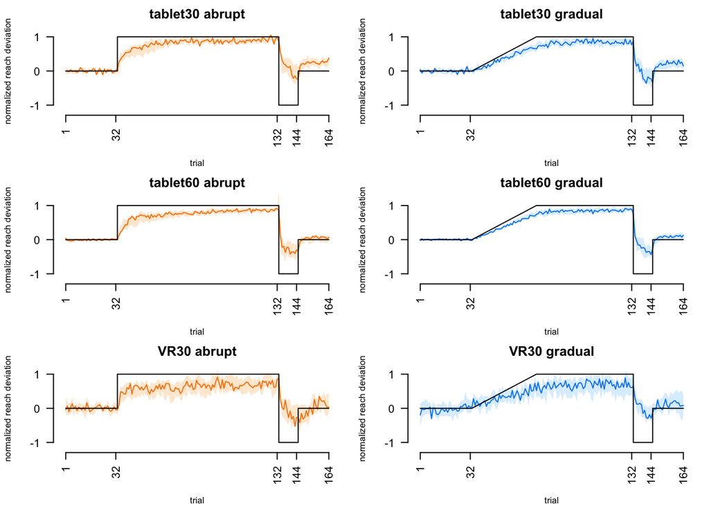

```r
plotAllData()
```

# Order Effects of Within-Subjects Design

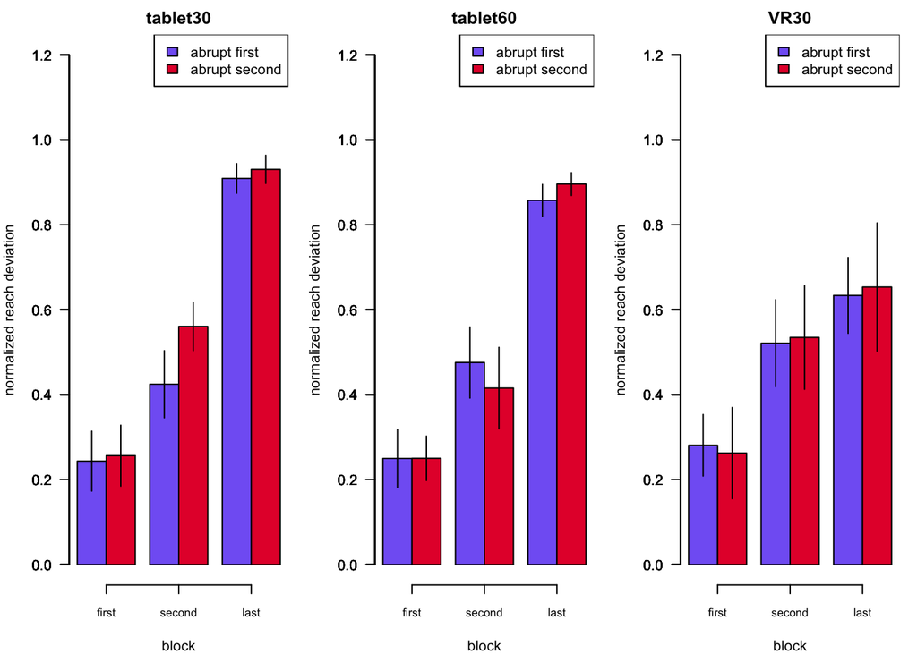

```r
plotOrderData()
```

Here is the ANOVA for each of the tablet30 group, which showed no effect of order.

```r
orderANOVA(group = 'tablet30')
```

```
## $ANOVA
##        Effect DFn DFd          F            p p<.05        ges
## 2       order   1  28   0.723500 4.022137e-01       0.01547996
## 3       block   2  56 107.157288 7.193161e-20     * 0.59972241
## 4 order:block   2  56   1.105181 3.382646e-01       0.01521742
##
## $`Mauchly's Test for Sphericity`
##        Effect         W         p p<.05
## 3       block 0.9488241 0.4920474
## 4 order:block 0.9488241 0.4920474
##
## $`Sphericity Corrections`
##        Effect       GGe        p[GG] p[GG]<.05      HFe        p[HF]
## 3       block 0.9513156 5.137529e-19         * 1.018806 7.193161e-20
## 4 order:block 0.9513156 3.362093e-01           1.018806 3.382646e-01
##   p[HF]<.05
## 3         *
## 4
```

Here is the ANOVA for each of the tablet60 group, which showed no effect of order.

```r
orderANOVA(group = 'tablet60')
```

```
## $ANOVA
##        Effect DFn DFd            F            p p<.05          ges
## 2       order   1  26  0.009481915 9.231753e-01       0.0002318619
## 3       block   2  52 88.074921744 2.006145e-17     * 0.5522311586
## 4 order:block   2  52  0.528464898 5.926413e-01       0.0073456288
##
## $`Mauchly's Test for Sphericity`
##        Effect         W         p p<.05
## 3       block 0.8972168 0.2577612
## 4 order:block 0.8972168 0.2577612
##
## $`Sphericity Corrections`
##        Effect       GGe        p[GG] p[GG]<.05       HFe        p[HF]
## 3       block 0.9067965 5.167944e-16         * 0.9709382 5.522909e-17
## 4 order:block 0.9067965 5.755789e-01           0.9709382 5.874898e-01
##   p[HF]<.05
## 3         *
## 4
```

Here is the ANOVA for each of the VR30 group, which showed no effect of order.

```r
orderANOVA(group = 'VR30')
```

```
## $ANOVA
##        Effect DFn DFd           F            p p<.05          ges
## 2       order   1  17 0.001798478 0.9666671996       6.138754e-05
## 3       block   2  34 9.774540542 0.0004429525     * 1.944044e-01
## 4 order:block   2  34 0.028268511 0.9721501280       6.974172e-04
##
## $`Mauchly's Test for Sphericity`
##        Effect         W         p p<.05
## 3       block 0.9426206 0.6232977
## 4 order:block 0.9426206 0.6232977
##
## $`Sphericity Corrections`
##        Effect       GGe        p[GG] p[GG]<.05      HFe        p[HF]
## 3       block 0.9457344 0.0005875801         * 1.060541 0.0004429525
## 4 order:block 0.9457344 0.9672409985           1.060541 0.9721501280
##   p[HF]<.05
## 3         *
## 4
```

# Extent of Learning

Here we are checking if there are any differences in the extent of learning in the abrupt and gradual conditions during the last training and last reversal blocks. The data is shown for the 3 groups (30° digitizing tablet, 60° digitalizing tablet, 30° VR setups). The orange bars here represent the mean reach deviations of the abrupt condition, and the blue bars represent the mean reach deviations of gradual condition. All of the data has been normalized to the size of the rotation.

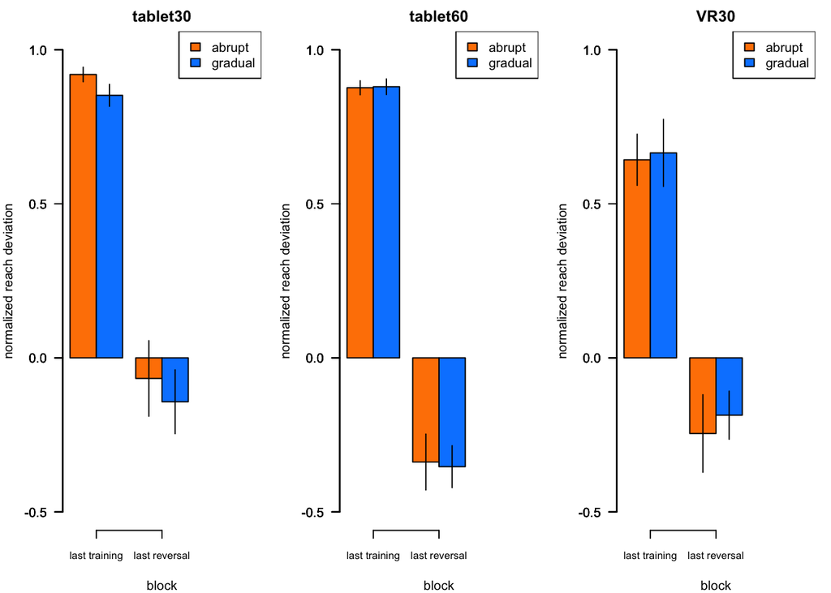

```r
plotExtentofLearning()
```

```r
ExtentOfLearningANOVA()
```

```
## $ANOVA
##                  Effect DFn DFd            F            p p<.05
## 2                 setup   1  47 4.925214e+00 3.133112e-02     *
## 3             condition   1  47 2.218709e-01 6.397971e-01
## 5                 block   1  47 1.799967e+02 1.095251e-17     *
## 4       setup:condition   1  47 8.470449e-01 3.620895e-01
## 6           setup:block   1  47 6.986461e-01 4.074683e-01
## 7       condition:block   1  47 9.622934e-03 9.222728e-01
## 8 setup:condition:block   1  47 5.214147e-02 8.203686e-01
##            ges
## 2 3.477118e-02
## 3 1.014410e-03
## 5 5.346182e-01
## 4 3.861714e-03
## 6 4.439099e-03
## 7 2.890201e-05
## 8 1.565843e-04
```

# Rebound

Here we are checking if there are any differences in the rebound between the abrupt and gradual conditions for the 3 groups (30° digitizing tablet, 60° digitalizing tablet, 30° VR setups). The orange bars here represent the mean reach deviations of the abrupt condition, and the blue bars represent the mean reach deviations of gradual condition. All of the data has been normalized to the size of the rotation.

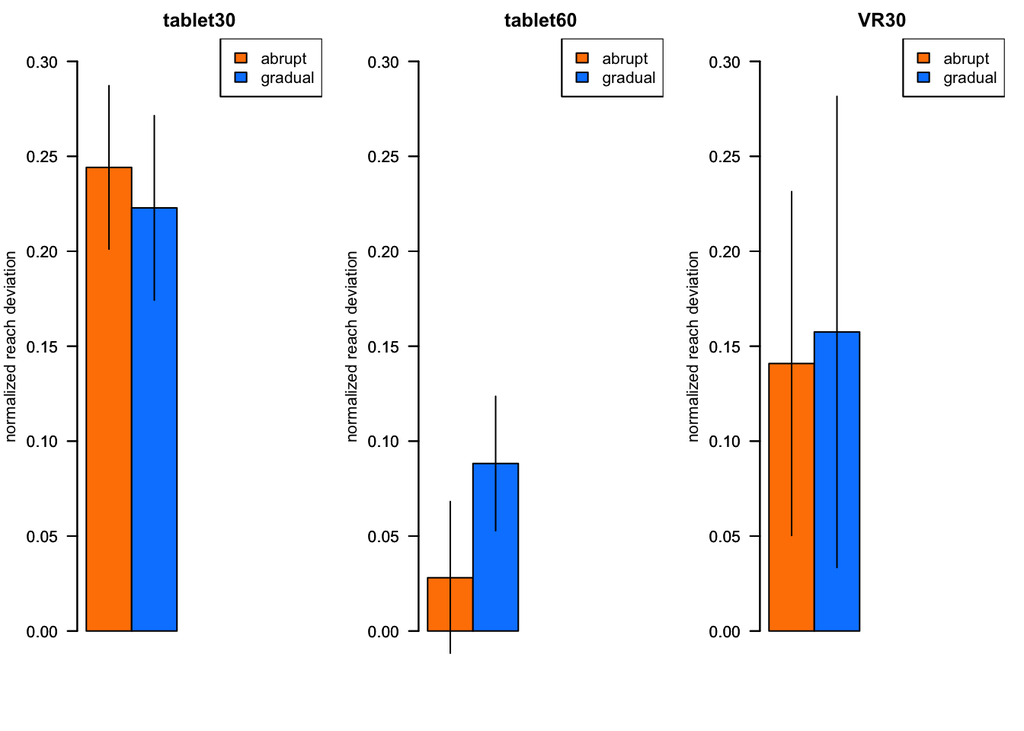

```r
plotReboundData()
```

```r
setupReboundANOVA()
```

```
## $ANOVA
##            Effect DFn DFd          F            p p<.05         ges
## 2           setup   1  57 14.2558022 0.0003827086     * 0.131407866
## 3       condition   1  57  0.2490659 0.6196543344       0.001723414
## 4 setup:condition   1  57  1.1780314 0.2823262885       0.008099336
```